# Analyzing the Age of Victims in Context of Demographics in Fatal Police Shootings - Project 1 Report

Berkeley Ho

2022-09-18

# **I. Introduction**

In this report, demographics pertaining to fatal police shootings between 2015 and 2019 are examined specifically within the context of the age of victims. Data was collected by the Washington Post from local news sources, social media, law enforcement websites, and fatal police shooting databases. More than 6000 observations record the age, gender, and race of victims. Variables specifically regarding the shooting are recorded also, including how the victim was fleeing, the threat level (determined by the threat to officers’ life), and if the victim was armed. The relationships between the victim’s gender, race, and if they were fleeing are analyzed with respect to the victim’s age.

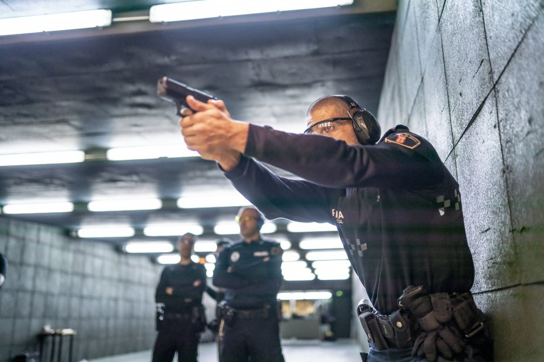

Officer Training

# **II. Distribution of Shooting Victims by Age**

*For graphing and analysis purposes, victims whose ages are unknown/not recorded have been removed from the data set*

The distribution of victims by age has a right skew to the older ages within the distribution, meaning that the median and quartiles would be the most optimal set of descriptive statistics to describe the distribution of age. The median age of shooting victims is 35 years. The first quartile is 27 years, and the third quartile is 45 years. 25% of shooting victims are younger than 27 years old, and 50% of all victims are between 27 and 45 years old.

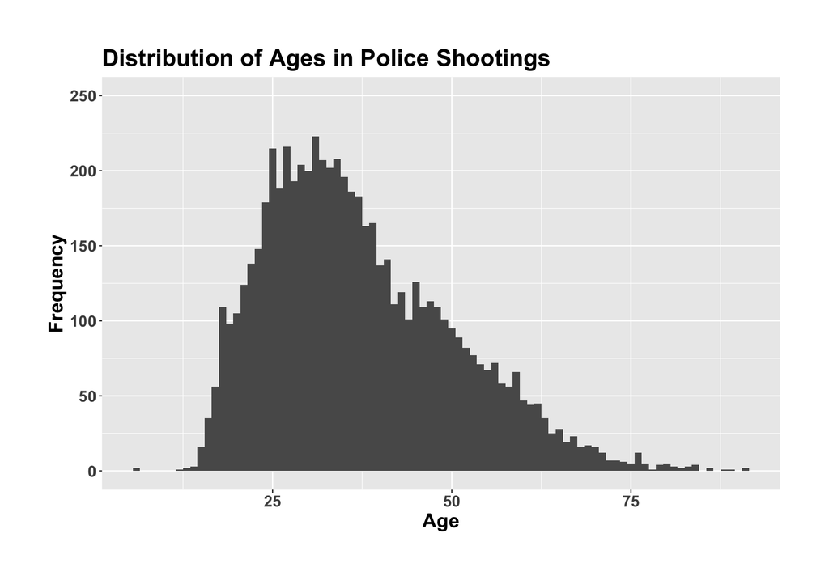

# **III. Predictor Variable Graphs**

## **A. Race**

Within the graph and table, Native American and African American victims have the lowest median age of shooting victims of a specific racial group at 31 years old. White victims have the highest median age, at 38 years old. With a difference of 7 years, if a victim is African American or Native American, they are more likely to be younger in age. Conversely, if the victim is white, they are more likely to be older. The other recorded racial groups included Hispanic and Asian peoples fall in between this range.

Table of Median Ages by Race

| Race | Age |
| --- | --- |
| African American | 31 |
| Asian | 35 |
| Hispanic | 33 |
| Native American | 31 |
| Other | 30 |
| Unknown | 40 |
| White | 38 |

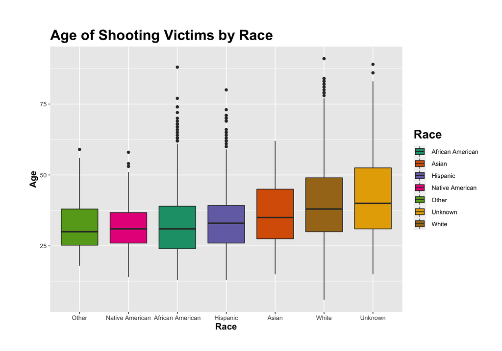

## **B. Gender**

Within the table, of the victims who were male, the median age was 35 years old. 50% of male victims were between the ages of 27 and 45, as seen in the table and graph. Victims who were female had similarly statistics, with a median age of 36 years old, and 50% of victims were between 28 and 46.75 years old. Victims of an unknown gender had a much different quartile range, but there were only 3 victims of an unknown gender who were observed in the study. As a result, differences in gender do not indicate much of a difference between the age of shooting victims.

Table of Quartile Ages by Gender

|  | Frequency | 0% | 25% | 50% | 75% | 100% |
| --- | --- | --- | --- | --- | --- | --- |
| Female | 290 | 12 | 28.00 | 36.0 | 46.75 | 91 |
| Male | 6276 | 6 | 27.00 | 35.0 | 45.00 | 91 |
| Unknown | 3 | 21 | 24.25 | 27.5 | 30.75 | 34 |

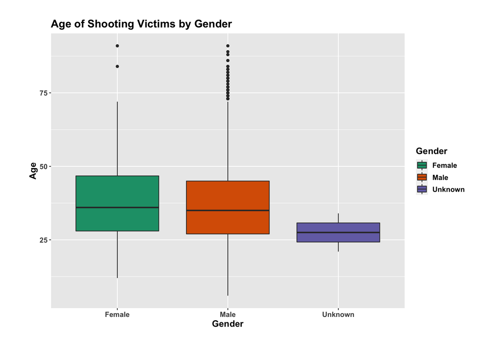

## **C. Fleeing Factor**

Table of Quartile Ages by Fleeing Factor

|  | Frequency | 0% | 25% | 50% | 75% | 100% |
| --- | --- | --- | --- | --- | --- | --- |
| Car | 1056 | 6 | 26 | 33 | 41.0 | 80 |
| Foot | 842 | 13 | 24 | 31 | 37.5 | 79 |
| Not Fleeing | 3943 | 6 | 29 | 37 | 48.0 | 91 |
| Other | 248 | 15 | 25 | 32 | 37.0 | 62 |
| Unknown | 480 | 15 | 28 | 36 | 47.0 | 82 |

[figure not shown]

# **IV. Conclusion**

Areas for future research could include investigating if there is a significant difference in ages when separated by both gender and race. Additionally, collecting more observations to increase the sample size and information available would improve the ability to determine a confidence interval for comparing if differences in data are significant.

### **Citations**

[*Police Shootings CSV: https://think.cs.vt.edu/corgis/csv/police_shootings/*](https://think.cs.vt.edu/corgis/csv/police_shootings/)

[*Image: https://havengear.com/blog/accessories-for-riot-gear/*](https://havengear.com/blog/accessories-for-riot-gear/)